# What is the Circular Drift Diffusion Model (CDDM)?

The Circular Drift-Diffusion Model (CDDM) is as a two-dimensional extension of the classical Drift-Diffusion Model where the decision space is represented as a bounded continuum, which constitutes the main difference with respect to the usual binary-choice setting. To capture this decision process, the CDDM model uses a circle to capture the space of possible answers to be observed, with its radius representing the threshold that defines the amount of information required to commit and report a particular value, once any given point on the circumference is reached.

Just as the classical DDM, the CDDM assumes that the system gathers information at each point in time to move from the initial starting point, which for an unbiased system refers to a point equally distant from every available decision bounds (i.e. the center of the circle), to any point on the circumference of the circle.

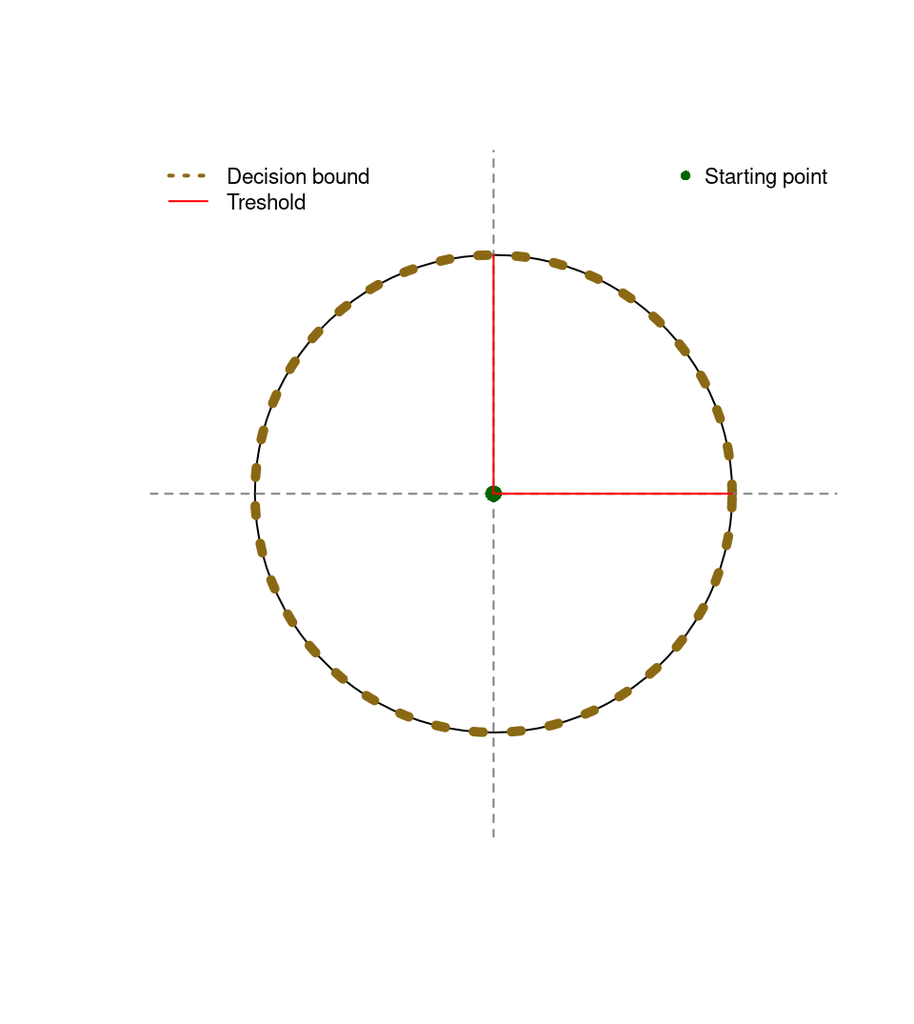

# 2. Single trial emulation of the decision process

To get a better understanding on how the CDDM works, let us emulate the decision process that takes place within any given trial.

```r
iter <- 5000       # Maximun number of steps/iterations for gathering information
thresh <- 7.5             # 1) Threshold for making a response (Radius)
s.init <- c(0,0)          # 2) Initial state; c(0,0) indicates no bias
mu1.drift <- 0.3          # 3) Average step size on X
mu2.drift <- 0.4          # 4) Average step size on Y
sigma.driftrate <- 0.6    # 5) Variance in the length of steps given in either X or Y

state <- matrix(nrow=iter,ncol=2) #Empty matrix to be filled with coordinates (states)
state[1,] <- s.init  #Declare initial state
```

In each moment in time, the system gathers information that moves the decision process from the initial state towards the circumference of the circle by an accumulation process similar to that described in the standard DDM, which finishes according to a stopping rule that compares the amount of information gathered at any moment versus the threshold set by the system.

```r
#Part 1: Acquiring/Accumulating/Updating information
for(t in 2:iter){    #In each iteration/step...
  d1 <- rnorm(1,mu1.drift,sigma.driftrate)  #A random step-size is sampled from a Normal distribution
  d2 <- rnorm(1,mu2.drift,sigma.driftrate)      #...for each, the X (d1) and Y (d2) axes
  state[t,] <- state[t-1,]+c(d1,d2)   #We update the information state

#Part 2: Evaluate whether we have passed the threshold
  pass <- sqrt(sum(state[t,]^2))  # The distance between current state and origin (0,0) is measured
  if(pass >= thresh){ #If this distance is greater than the threshold (a.k.a. ratio), then..
    print(paste("Finished in", t, "iterations"))  # We identify the number of iterations passed
    break}} #The accumulation process ends
```

```
## [1] "Finished in 25 iterations"
```

```r
#Part 3: Make sure the decision process and the line drawn end exactly at threshold
if(pass> thresh){   #If the last state is further away than the threshold (i.e. out of the circle)
  A <- state[t-1,]    #Then we take the second to last state
  B <- state[t,]      #and this final state as reference points
  last.step.x <- seq(A[1],B[1],length.out = 100)  #We define 100 different intermediate points
  last.step.y <- seq(A[2],B[2],length.out = 100)      #.. on each the X and Y axes
  for(i in 1:length(last.step.x)){    # Now, each of these middle points gets examined
    pass2 <- sqrt(last.step.x[i]^2+last.step.y[i]^2)  # in terms of their distance from origin
    if(round(pass2,1) == thresh){  # so that we can stop right at the threshold
      circunf <- c(last.step.x[i],last.step.y[i]) #and locate the exact point on the circumference
      break}} # where the decision process ends
  state[t,] <- circunf} #and we redefine our final state
```

# Plotting the single-trial random-walk process

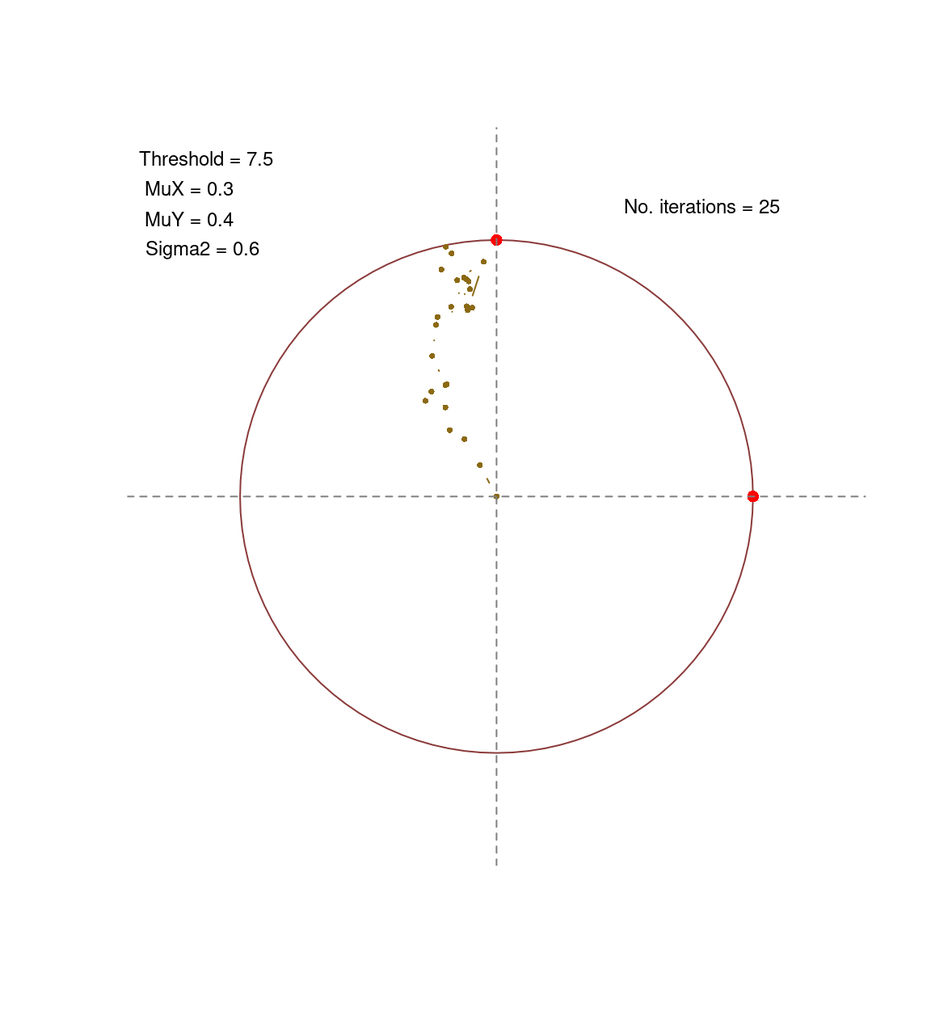

```r
library(plotrix) #Library to draw circles
plot(-10:10,-10:10,type="n", ann = FALSE, axes = FALSE) #Create empty plot
draw.circle(0,0,radius = thresh, border = "indianred4") #Draw circle
points(state, type = "b", col = "goldenrod4", pch=16, cex=0.5) #Accumulation process
points(0,thresh, col ="red", pch=16) #Make sure ratio is correct on Y
points(thresh,0, col= "red", pch=16) #..and X axis
abline(h = 0, lty=2, col="gray50") # Draw reference lines at y=0
abline(v = 0, lty=2, col="gray50") #... and x=0
text(-8.5,9.9,paste("Threshold =", thresh), cex = 0.75) #Print values used on our emulation
text(-9,9,paste("MuX =", mu1.drift), cex = 0.75)
text(-9,8.1,paste("MuY =", mu2.drift), cex = 0.75)
text(-8.6,7.2,paste("Sigma2 =", sigma.driftrate), cex = 0.75)
text(6,8.5,paste("No. iterations =", t), cex = 0.75)
```

# 3. Multiple trials

The accumulation process illustrated in our previous emulation is the result of randomly sampling different “step sizes” that determine how much we move in the X and Y axis on any given point in trial. In other words, there are multiple outcomes possible for any given combination of true values for mu1, mu2 and sigma, with some of them being more likely than others.

For example, let us observe what would happen if we were to repeat the very same accumulation process 200 times:

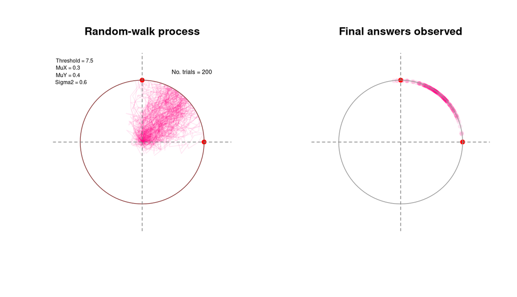

```r
trials <- 200  #Number of repetitions of the accumulation process
state <- array(NA, dim = c(iter, 2, trials))   #States are saved in a 3dimensional array
finalT <- NA #An additional empty vector to store RT (a.k.a. total number of iterations)

#This part of the code is exactly the same as before, except that:
for(a in 1:trials){  #1) Now we have an additional "for" loop for each trial
state[1,,a] <- s.init   #2) and States are stored in our new 3D array
for(t in 2:iter){
  d1 <- rnorm(1,mu1.drift,sigma.driftrate)
  d2 <- rnorm(1,mu2.drift,sigma.driftrate)
  state[t,,a] <- state[t-1,,a]+c(d1,d2)
  pass <- sqrt(sum(state[t,,a]^2))
  if(pass >= thresh){
    finalT[a] <- t   #We store the number of total iterations required on each trial
    break}}

if(pass> thresh){
  A <- state[t-1,,a];   B <- state[t,,a]
  last.step.x <- seq(A[1],B[1],length.out = 100)
  last.step.y <- seq(A[2],B[2],length.out = 100)
  for(i in 1:length(last.step.x)){
    pass2 <- sqrt(last.step.x[i]^2+last.step.y[i]^2)
    if(round(pass2,1) == thresh){
      circunf <- c(last.step.x[i],last.step.y[i])
      break}}
  state[t,,a] <- circunf}}

par(mfrow = c(1,2))  ################ Include 2 plots
# First we present all the random-walk processes registered for every trial
plot(-10:10,-10:10,type="n", ann = FALSE, axes = FALSE)
for(b in 1:trials){ # Add a different line per trial
  points(state[,,b], type = "l", col=rgb(1,0,0.5,0.1))}
points(0,thresh, col ="red", pch=16);points(thresh,0, col= "red", pch=16)
draw.circle(0,0,radius = thresh, border = "indianred4")
abline(h = 0, lty=2, col="gray50"); abline(v = 0, lty=2, col="gray50")
text(-8.2,9.9,paste("Threshold =", thresh), cex = 0.5)
text(-9,9,paste("MuX =", mu1.drift), cex = 0.5)
text(-9,8.1,paste("MuY =", mu2.drift), cex = 0.5)
text(-8.6,7.2,paste("Sigma2 =", sigma.driftrate), cex = 0.5)
text(6,8.5,paste("No. trials =", trials), cex = 0.55)
mtext("Random-walk process", 3, line=1.2, f=2)
# Then, we focus merely on the final choices registered.
plot(-10:10,-10:10,type="n", ann = FALSE, axes = FALSE)
for(b in 1:trials){ #Take just the last state
  points(state[finalT[b],1,b], state[finalT[b],2,b], pch =16, cex=0.9, col=rgb(1,0,0.5,0.1))}
points(0,thresh, col ="red", pch=16); points(thresh,0, col= "red", pch=16)
draw.circle(0,0,radius = thresh, border = "gray60")
abline(h = 0, lty=2, col="gray50"); abline(v = 0, lty=2, col="gray50")
mtext("Final answers observed", 3, line=1.2, f=2)
```

From the plots presented above, we can tell that certain regions of the circumference are reached with a higher frequency than others. In fact, there are multiple points on the circumference that weren’t observed even once.

## Distribution of RT (total no. of iterations) required

If we plot a histogram for the Response Times registered across trials (a.k.a. the total number of iterations needed to reach the threshold), we get a positive-biased curve that aligns with what we would expect based on the literature.

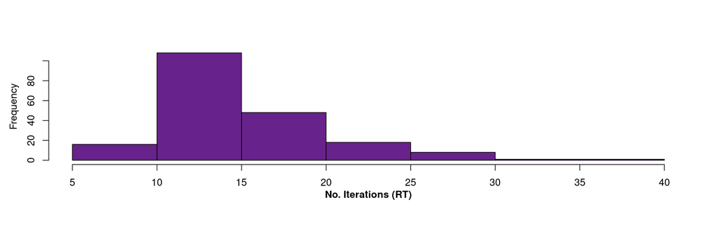

```r
hist(finalT, col = "darkorchid4", breaks = 10, ann=FALSE)
mtext("No. Iterations (RT)", 1, line=2, f=2)
mtext("Frequency", 2, line = 2.5)
```

# 5. Parameter interpretation and assumptions

## Starting point

The evidence accumulation process is captured at each point in time as a pair of x,y coordinates that are assumed to move from an initial point towards a specific location on the circumference.

For an unbiased system, the starting point is assumed to be located at the origin (0,0), since this would imply that the accumulation process needs to cover the same distance to reach the circumference of the circle at any given point from its initial state.

All the methods presented in the present report were developed for unbiased systems.

## Threshold ($a$)

Under the CDDM, the ratio of the circle used to represent the set of choices available to the observer represents the threshold (often also referred to as the “criteria” or “boundary”) that determines how much information the system needs to gather in order to produce a certain response, depending on at which point the accumulation process crosses the circumference.

The threshold is assumed to be under the decision-maker’s control and it is assumed to have a strong impact on the speed-accuracy trade-off settings of the task. Overall, higher criteria lead to slower but more accurate responses, as it takes more time for the system to reach the circumference.

## Drift rates ($\mu_1$ and $\mu_2$)

The drift rate parameters $\mu_1$ and $\mu_2$ are used to capture the mean sizes of the steps observed on the x and y axes (i.e. the rate of evidence growth) on each iteration of the information accumulation process.

The drift rate parameters are assumed to depend directly on how informative the stimulus observed is (i.e. the quality of the information it contains), so that non-informative stimuli would be characterized by $\mu_1=0$ and $\mu_2=0$ (i.e a “zero-drift’ process) where the final response is assumed to be produced at random.

The zero-drift process is radially symmetrical (every response becomes equally likely to be observed), whereas a nonzero-drift process wouldn’t.

## Diffussion coefficient ($\sigma^2$)

The diffusion coefficient represent a stimulus-independent source of variation (i.e. spread of evidence) and it is assumed to be independent and identical across the horizontal and vertical growth of the evidence accumulation process.

# 6. Angle response

Let us now work a couple of functions in R that serve us for this purpose, first transforming the x,y coordinates into a degree angle, and then using this transformed value as the input for a different function, which retrieves the angle measured in radians.

```r
#X,Y coordinates are transformed into an angle (in degrees)
theta.d <- function(x,y){   #This function takes the X,Y coordinates as inputs
  theta <- atan2(y,x) * 180 / pi  #Angle with respect of y=0
  if(theta<0){theta <- theta+360}   #Correction for whole circle (360)
  return(theta)} #return Theta value
#The angle (in degrees) is now express in radians.
theta.r <- function(theta.d){  #This functiont takes angle in degrees as input
  theta <-  theta.d * pi /180  #Transform to radians
  return(theta)}
```

As an example, let’s work with the angle corresponding to the coordinates registered in the last trial.

```r
x <- state[t,1,trials]   #Final state x coordinate recorded
y <- state[t,2,trials]   #Final state y coordinate recorded
angle <- theta.d(x,y); angle
```

```
## [1] 37.85824
```

```r
radians <- theta.r(angle); radians
```

```
## [1] 0.6607509
```

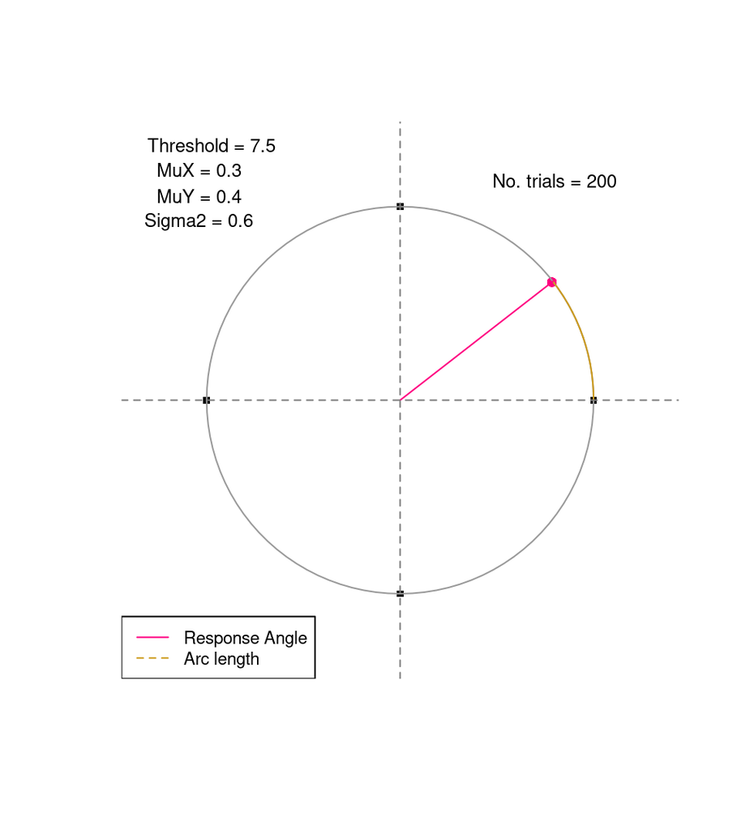

```
draw.arc(0,0,thresh,angle1=0,angle2=angle, col = "red")
draw.radial.line(0,thresh,c(0,0),angle = angle, col="purple")
```

# 7. Responses and Response Times (Probability functions)

From our initial simulation presented in Section 2, we know that there are 5 different parameters that we need to specify in order to be able to emulate the information accumulation process that takes place on any given trial:

1. Initial state (s.init)
2. Threshold (thresh)
3. Average step size on X (Mu.1)
4. Average step size on Y (Mu.2)
5. The variance on the steps size

The model establishes that the probability of observing a certain response (as defined by its angle $\theta$, measured in radians) with Response Time $t$ ($\mbox{Pr}(\mbox{Angle}=\theta \cap RT=t)$) is defined as:

$$\begin{align*}
\mbox{Pr}(\mbox{Angle}=\theta \cap RT=t)=
\Big[\mbox{exp}(\frac{a(\mu_1\cos(\theta)+\mu_2\sin(\theta))}{\sigma^2})-
\frac{|\mu|^2(t-t_{ND})}{2\sigma^2}\Big] \times
\Big[\frac{\sigma^2}{a^2}\sum_{k=1}^n\frac{j_{0,k}}{J_1(j_{0,k})}\mbox{exp}(-\frac{j^2_{0,k}\sigma^2(t-t_{ND})}{2a^2})\Big]
\end{align*}$$

Under the CDDM framework, the angle corresponding to the response observed is assumed to be independent from the RT registered, and so the equation presented consists on the product of what can be think of as two different functions: a function describing the probability of observing a certain response angle (first square bracket) and a function related to the probability of observing a certain response time (second square bracket).

```r
## Write our probability function in R for the CDDM model:
probFunction <- function(theta,mu1,mu2,sigma.driftrate,thresh,tnd){
  #### Step 1: Let's begin with some definitions
  mu.vector <- c(mu1,mu2)            # Define Mu vector
  mu.mag <- sqrt(sum(mu.vector^2))   # Magnitude of Mu vector

  ### Step 2: Let's work terms related to the Probability of Response
  pResp.frac1 <- (thresh*((mu.vector[1]*cos(theta))+(mu.vector[2]*sin(theta))))/(sigma.driftrate^2)
  pResp.frac2 <- ((mu.mag^2)*(t-tnd))/(2*(sigma.driftrate^2))
  pResp <- exp(pResp.frac1 - pResp.frac2)

  #### Step 3: Let's build terms related to the Probability of Response Time
  library(CircularDDM)  # Loading besselzero function
  bess <- NULL  #Empty vector to store outcome of bessel function
  for(k in 1:150){  #Iterate the sum up to n = 150
    j <- besselzero(0,k,1)
    pRT.frac1 <- j/besselJ(j,1)
    pRT.frac2 <- exp(-(((j^2)*(sigma.driftrate^2)*(t-tnd))/(2*(thresh^2))))
    b <- pRT.frac1 * pRT.frac2
    bess[k] <- sum(b)
      if(k>1){if(round(bess[k],3) == round(bess[k-1],3)){break}}} #End when convergence is achieved
  pRT.term1 <- (sigma.driftrate^2)/(thresh^2)
  pRT.term2 <- sum(bess)
  pRT <- pRT.term1 * pRT.term2
  probFunction <- pRT*pResp #Overall joint probability function
return(probFunction)} # Retrieve probability
```

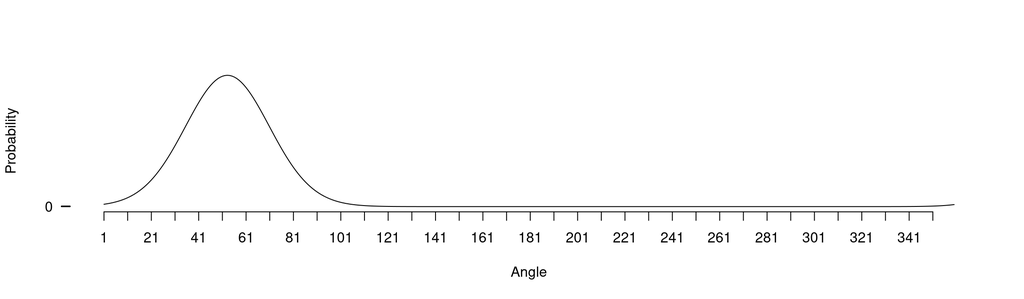

```r
tnd <- 0  # Define some No-decision time
angles <- seq(1,360,1)  # All possible angles
angles <- theta.r(angles) # Transform into radians
Probs <- NULL  #Empty vector to store probabilities
for(a in 1:length(angles)){ # For each angle defined compute the probability
    Probs[a] <- probFunction(angles[a],mu1.drift,mu2.drift,sigma.driftrate,thresh,tnd)}
```

Now, for comparison, let’s take a look at responses and response angles observed in our simulation..

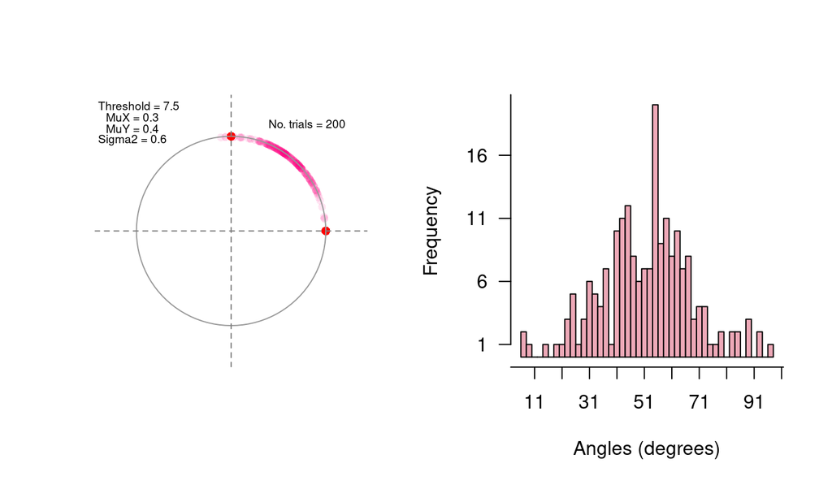

## Expected Angle response ($\theta_\mu$)

```r
PhaseAngle <- 1/tan((mu2.drift)/(mu1.drift)); PhaseAngle
```

```
## [1] 0.2420294
```

The phase angle is assumed to depend on the identity of the stimuli.

[figure not shown]

## Expected RT

From the density expressed in the joint probability function presented before, we can obtain the expected response time by computing the expectation after conditioning with respect to the hitting probability.

$$\begin{align*}
\tilde{E}[T] =
\frac{aI_1(\frac{a||\mathbf{\mu}||}{\sigma^2})}{||\mathbf{\mu}||
I_0(\frac{a||\mathbf{\mu}||}{\sigma^2})}
\end{align*}$$

```r
ExpRT <- function(thresh, mu1.drift, mu2.drift, sigma.driftrate){
  mus <- c(mu1.drift,mu2.drift)
  mu.mag <- sqrt(sum(mus^2))
  library(CircularDDM)
  Num <- thresh*besselI((thresh*mu.mag)/sigma.driftrate^2,1)
  Denom <- mu.mag*besselI((thresh*mu.mag)/sigma.driftrate^2,0)
  ExpRT <- Num/Denom
  return(ExpRT)}

ExpRT(thresh,mu1.drift,mu2.drift,sigma.driftrate)
```

```
## [1] 14.26074
```

## Response Time and Response Angle independence

For proof, let us explore the correlation between the response times and response angles observed in our simulated data:

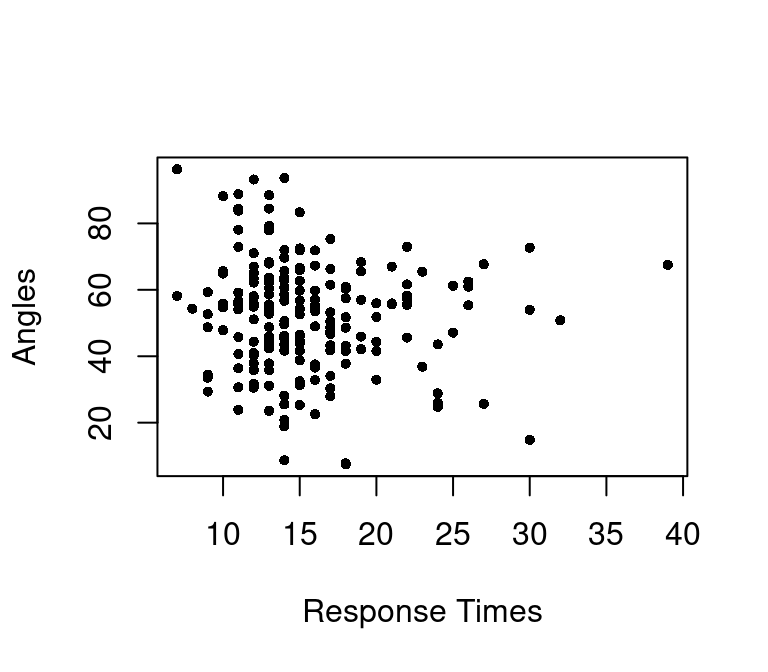

```r
cor(finalT,thetas) #Correlation between RT and Response Angles
```

```
## [1] -0.08726513
```

Let us define multiple subsets, so that we can observe the corresponding Response time histogram for each one of them:

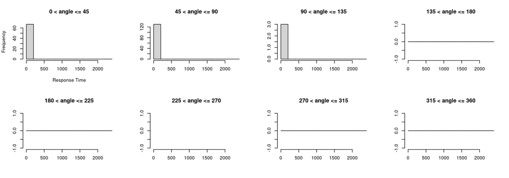

All of the histograms presented peak at very similar Response Times, even though the overall shape of these histograms isn’t exactly the same across subsets. This is most likely due to the fact that we only observed 200 trials, so that a few of these histograms correspond to very few occasions, or none at all.

With this in mind, we may want to repeat our simulation, this time using $10x$ trials:

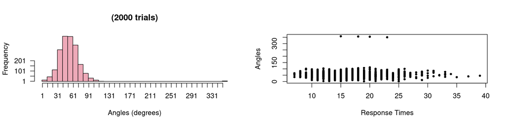

As we can see, the histogram of response angles observed on the 2,000 trials resembles even more the pattern portrayed by the pdf function previously presented. Furthermore, we confirm that there’s not a correlation between response angles and RTs ($\mbox{Corr}=$ 0.008334), which can also be appreciated if we plot again the different histograms for different angle subsets.

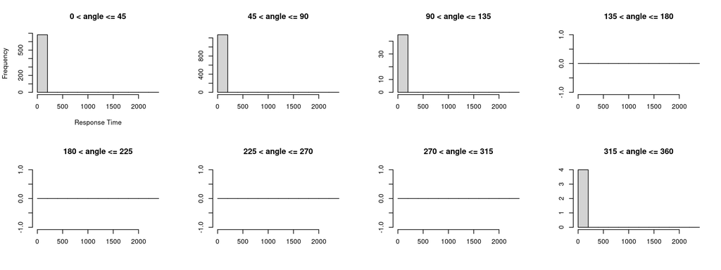